# IWAM Model Description and Comparison

Tor Kitching

2024-06-03

# 1 Introduction

The purpose of this report is to:

- Clearly and simply explain the background, usage, and differences of the IWAM-Ricker $S_{MAX}$ and $S_{REP}$ models
- Justify the usage of the new $S_{REP}$ parameterized model
- Introduce next steps in model development
- Walk through the outputs of both models

# 2 Datamap

The following function vignette/example is from the IWAM Package Repo hosted publicly through the Pacific Salmon Assess organization available at [this link.](https://github.com/Pacific-salmon-assess/iwam-package)

The package currently utilizes the following data sets:

- *SRinputfile (Private)*: Private data-sets developed by Parken et al. (2006). Required to run the complete function and is available upon request. To be updated with publicly available data. Life histories are included: 1 = ocean type, 0 = stream type. Contains stock names, year, spawners, recruits, and life history identification.
- *WatershedArea (Public)*: Internal input containing watershed areas per stock.
- *CUPars_nBC (Public)*: Input file with Ricker $\alpha$’s without bias correction (CITATION) from Diana Dobson’s Run Reconstruction coded in TMB. Has a higher estimate of Ricker $\alpha$ (lower Sgen).
- *CUPars_wBC (Public)*: Input file with Ricker $\alpha$’s with bias correction (CITATION) from Diana Dobson’s Run Reconstruction coded in TMB. Has a higher estimate of Ricker $\alpha$ (lower Sgen).
- *WCVIStocks (Public)*: User watershed area input file. Must contain watershed areas, life history identification, enhancement identification, and stock name. Aggregation within the IWAM function can be done with both CU and Inlet scales.

# 3 Overarching Model Flow

The model, regardless of its form between Parken et al., Leirmann et al., and Holt et al., follow the following three model stages:

1. Estimation of the Ricker model using 25 Chinook spawner and recruit time-series from across the NE Pacific
2. Regression of benchmarks derived from Ricker model parameters against the log(watershed areas) of the stocks included in the synoptic SR time series
3. Using the regression model, estimate *new* Ricker model parameters and benchmarks for stocks where only watershed area is known

The main differences between the models occur in the for formulation of the Ricker model, and how error is propagated between steps. These differences will be explored in the following document.

# 4 Model Variants

To describe the two main forms of the IWAM model, we will go step by step through the previously described steps, beginning with the core stock-recruitment model, the Ricker model.

- Clearly and simply explain the background and usage of
  - the IWAM-Ricker (SMAX) model
    - Based on the Ricker model parameterizd from $\beta$ (or 1/$S_{MAX}$), as in Parken et al. (2006) and Holt et al. 2023 .
    - Written initially in TMB - translated currently to rTMB/tmbstan
  - the IWAM-Ricker (SREP) model
    - Based n the Ricker model parameterized from $S_{REP}$, as in Liermann et al. (2010)
    - Written initially in NIMBLE by Paul and Tor - translated to rTMB/tmbstan
  - Identify the core differences between the two model variants
    - The parameterization of the Ricker model with $\beta$ (or 1/$S_{MAX}$) vs $S_{REP}$
    - Methods of estimation: frequentist vs. bayesian (maximum likelihood vs. mcmc)
    - Parameterized to estimate both benchmarks $S_{REP}$ and $S_{SMSY}$, or only $S_{REP}$
    - Both models variants are statistically integrated, in contrast to Parken et al. (2006) which is sequential

## 4.1 $S_{MAX}$ (IWAM-Ricker)

Following Parken et al. 2006 and Holt et al. 2023 the SMAX Ricker model is predominantly expressed in the following form:

$$\begin{equation}
R = S e^{log(\alpha)- \beta S}e^\tau
\tag{4.1}
\end{equation}$$

Where $R$ is the abundance of adult recruits expressed as a $numeric$,

$S$ is spawner abundance expressed as a $numeric$. Is it standard that both recruits and spawners be scaled values for modelling. In the case of the IWAM package, both recruits and spawners are transformed by divided by $10^x$ where $x$ is the maximum number of digits across the per-stock timeseries.

$\alpha$ is the dimensionless number of recruits per spawner produced at low spawner density (productivity), this may also be thought of as the intercept of the relationship between $\frac{R}{S}$ and $S$,

$\beta$ is the strength of the density dependence expressed as $1/S_{MAX}$ $spawners^{-1}$, which can be described as the slope of the previously described relationship,

and $\tau$ represents normally distributed random error which accounts for process and environmental variability.

This is the form used in both the Parken et al. (2006) and the Holt et al. (2023) models.

This model can be linearized for ease of estimation. Further, following Liermann et al. (2010), hierarchical structure is added to the productivity parameter to improve model fit for data-limited populations:

$$\begin{equation}
log(\frac{R_i}{S_i}) = log(\alpha)-\beta \cdot S_i - \frac{\sigma_{\tau,i}^2}{2}
\tag{4.2}
\end{equation}$$

Where $i$ is the year class per stock,

and,

$$\begin{equation}
log(\frac{R}{S}) \sim N(log(\frac{R}{S}), \sigma_{\tau, i})
\tag{4.3}
\end{equation}$$

and the mean is adjusted by $\frac{-\sigma_{\tau,i}^2}{2}$ to account for the log back-transformation adjustment with the following distribution:

$$\begin{equation}
\frac{1}{\sigma_{\tau, i}^2} \sim Gamma(0.1, 10)
\tag{4.4}
\end{equation}$$

$\alpha$ is the intercept and $\beta$ is the slope of the spawner-recruit relationship, where $log(\alpha)$ has a hierarchical prior:

$$\begin{equation}
log(\alpha) \sim N(\mu_{\alpha,Stream} + \mu_{\alpha,Ocean} \cdot LH, \sigma_\alpha)
\tag{4.5}
\end{equation}$$

$\mu_\alpha$ varies between stream and ocean life histories ($LH$), a 0-1 binary offset, where,

$$\begin{equation}
\mu_{\alpha,Stream} \sim N(1.5,2)
\tag{4.6}
\end{equation}$$

$$\begin{equation}
\mu_{\alpha,Ocean} \sim N(0,2)
\tag{4.7}
\end{equation}$$

$$\begin{equation}
\frac{1}{\sigma_{\alpha}^2} \sim Gamma(0.1,10)
\tag{4.8}
\end{equation}$$

Once the Ricker model parameters ($\alpha$ and $\beta$) have been estimated and used to calculate $S_{MSY}$ and $S_{REP}$ (for full equations see Benchmark Estimation. Using the synoptic benchmark estimates, the following regression model is estimated with watershed area:

$$\begin{equation}
log(S_{MSY}) = log(\delta_0) + \delta_1 \cdot log(WA) + \delta_\epsilon
\tag{4.9}
\end{equation}$$

$$\begin{equation}
ln(S_{REP}) = ln(\gamma_o) + \gamma_1 \cdot ln(WA) + \gamma_\epsilon
\tag{4.10}
\end{equation}$$

$$\begin{equation}
\delta_\epsilon \sim N(0,\sigma_\delta^2)
\tag{4.11}
\end{equation}$$

$$\begin{equation}
\gamma_\epsilon \sim N(0,\sigma_\gamma^2)
\tag{4.12}
\end{equation}$$

$$\begin{equation}
\frac{1}{\sigma_{\delta,\epsilon}^2} \sim Gamma(1,1)
\tag{4.13}
\end{equation}$$

$$\begin{equation}
log(S_{MSY}) = log(\delta_{0,stream}) + log(\delta_{0,ocean}) \cdot X + (\delta_{1,stream} + \delta_{1,ocean} \cdot X) \cdot log(WA) + \delta_\epsilon
\tag{4.14}
\end{equation}$$

$$\begin{equation}
\delta_\epsilon \sim N(0,\sigma_\epsilon^2)
\tag{4.15}
\end{equation}$$

where, $X = 0$ for stream type and $X = 1$ is for ocean type populations. This form is then repeated with a new set of parameters to estimate $S_{REP}$ from watershed area.

Once these regression models are estimated, the $\delta$ parameters are used to predict $S_{REP}$ or $S_{MSY}$ for populations where only watershed area is known. When both $S_{REP}$ or $S_{MSY}$ are predicted for a given population (as in Parken et al. 2006), the productivity parameter can be inferred as it is determined exactly from the two benchmarks. This inference of productivity is informed by the underlying spawner-recruitment time-series used to parameterize the model, and can be used to estimate other benchmarks, e.g., $S_{gen}$.

When implementing this model for WCVI Chinook (Holt et al. 2023), the inference of productivity was identified as being implausible (recruits/spawner >7) given low estimates of productivity determined from life-cycle models on these populations (recruits/spawners 2-3). Instead of using watershed-area derived estimate of $S_{MSY}$, Holt et al. (2023) derived bootstrapped distributions of benchmarks $S_{MSY}$ and $S_{gen}$ by drawing from independent distributions of productivity derived either from a life-cycle model or a run-reconstruction and a distribution of $\S_{REP}$ values from the watershed-area model. In future model updates, $\alpha$ could instead be estimated as a regionally hierarchical parameter within the IWAM model and the watershed area regression could use regional groupings as co-variates to predict benchmarks, thereby explicitly accounting for differences in productivities among areas. Alternatively, Liermann et al. (2010) used the formulation of the Ricker based on $S_{REP}$ and predicted only $S_{REP}$ from watershed area, avoiding inferences about productivity.

Here, we follow Holt et al. (2023) to derive bootstrapped uncertainty intervals drawing from distributions for $\alpha$ and the regression model estimates of $S_{REP}$, following these steps:

- Re-estimate $\beta$ as $\beta = log(\alpha)/S_{REP}$
- Re-estimate $S_{MSY}$ with the above $\beta$
- Optimize for an estimate of $S_{GEN}$ using the supplied $\alpha$ and new $\beta$ (See Benchmark estimation for complete equation)

With the optimization complete, we are now supplied with our final estimates of $S_{GEN}$, $S_{MSY}$, and $S_{REP}$.

## 4.2 $S_{REP}$ (IWAM-Ricker)

The following model is based off of Liermann et al. 2010. The main difference between this formulation of the Ricker model and the one used by Parken et al. (2006) and Holt et al. (2023) is parameterization of $S_{REP}$ instead of $\beta$ (1/$S_{MAX}$).

$$\begin{equation}
R_{ij} = S_{ij}e^{log(\alpha_j)(1-\frac{S}{S_{REP_{ij}}})+w_{ij}}
\tag{4.16}
\end{equation}$$

where $i$ is year class,

$j$ is population,

where $R$ is the number of recruits,

$S$ is the number of spawners,

and, $S_{REP}$ is the point on the curve where $R = S$, also defined as the unfished equilibrium point, $S_{REP} = \frac{log\alpha}{\beta}$.

$\alpha_j$ is the $log(slope)$ where $S_{ij} = 0$, with the following prior of:

$$\begin{equation}
\alpha_j \sim N(\alpha_m, h_j)
\tag{4.17}
\end{equation}$$

$$\begin{equation}
\alpha_m \sim N(0.6, 0.45)
\tag{4.18}
\end{equation}$$

$$\begin{equation}
h_j \sim N(0, E_{SD})
\tag{4.19}
\end{equation}$$

$$\begin{equation}
E_{SD} \sim Uniform(0,100)
\tag{4.20}
\end{equation}$$

and, $w_{ij}$ is the normally distributed independent random variable with mean 0 and population specific standard deviation.

To avoid confusion, please keep in mind that Liermann substitutes $\alpha$ for $r$ as a the productivity parameter. We have opted to maintain the nomenclature of $\alpha$ as per the original Ricker equation. This also goes for the reference to $S_{REP}$, which you will see is renamed as $E$ in the Liermann notation. All nomenclature across the model types has been made as close as possible to aid in comparison and evaluation.

This is evaluated as:

$$\begin{equation}
log(\frac{R}{S}) \sim N(log(\frac{R}{S}_{pred}), \tau_{obs})
\tag{4.21}
\end{equation}$$

where $\tau$ is the stock-specific precision defined as,

$$\begin{equation}
\tau_{obs} \sim Gamma(0.001, 0.001)
\tag{4.22}
\end{equation}$$

With the Ricker parameters defined, the regression is then evluated based on $E$.

$$\begin{equation}
log(S_{REP_j}) = b0_{stream,ocean} + bWA_{stream,ocean}*log(WA_j) + log(E0_j)
\tag{4.23}
\end{equation}$$

where $b0$ is the intercept (either river or ocean),

$$\begin{equation}
b0 \sim N(0, \tau = 0.001)
\tag{4.24}
\end{equation}$$

$bWA$ is the slope (either river or ocean),

$$\begin{equation}
bWA \sim N(0, \tau = 0.001)
\tag{4.25}
\end{equation}$$

where $WA$ is the watershed area $(km^2)$ for the population

and $E0$ is the stock-level random-effect, with the following prior:

$$\begin{equation}
log(E0_j) \sim N(0, log(E_{SD}))
\tag{4.26}
\end{equation}$$

$$\begin{equation}
log(E_{SD}) \sim Uniform(0, 100)
\tag{4.27}
\end{equation}$$

Armed now with the regression coefficients $b0$ and $bWA$ we estimate new stock $S_{REP}$’s, and assuming the same global $\alpha$ estimate $S_{MSY}$ and $S_{GEN}$.

## 4.3 Benchmark Estimation

The final outcome of the IWAM model is the calculation of stock assessment benchmarks, either $S_{MSY}$, $S_{REP}$, or $S_{GEN}$. If the $S_{MAX}$ model form is used, $S_{REP}$ can be calculated using the Ricker estimated $\alpha$ and $\beta$. The $S_{REP}$ model requires no additional calculation.

$$\begin{equation}
S_{REP} = \frac{log(\alpha)}{\beta}
\tag{4.28}
\end{equation}$$

For both the $S_{MAX}$ and $S_{REP}$ models the solution to $S_{MSY}$ is solved with a Lambert W equation defined by Schueurel (2016). The only exceptions are that we use an explicit form of Lambert’s W, where the original SMAX model form had a non-explicit optimization method.

$S_{MSY}$, $\beta$, and $\alpha$ are then used in the final calculation of $S_{GEN}$, shown in its explicit form here as:

$$\begin{equation}
S_{GEN} = \frac{-1}{\beta} \cdot LambertW(-\beta \cdot \frac{S_{MSY}}{\alpha})
\tag{4.30}
\end{equation}$$

```r
# Proving the relationship between logalpha and logWA

logalpha <- 1.5 # 1.5

beta <- 0.0001


Srep <- logalpha/beta

Smsy <- (1-gsl::lambert_W0(exp(1-logalpha)))/beta

a <- Smsy/Srep

logalpha.hat <- (a*(-gsl::lambert_W0(((a-1)*exp(1-1/a))/a)) + a - 1)/((a-1)*a)
  # back-simulated alpha based on predicted Srep and Smsy

beta.hat <- logalpha.hat/Srep
  # back-simulated beta

beta.hat - beta
```

```
## [1] -5.421011e-20
```

```r
  # back-simulated beta

logalpha.hat - logalpha
```

```
## [1] -6.661338e-16
```

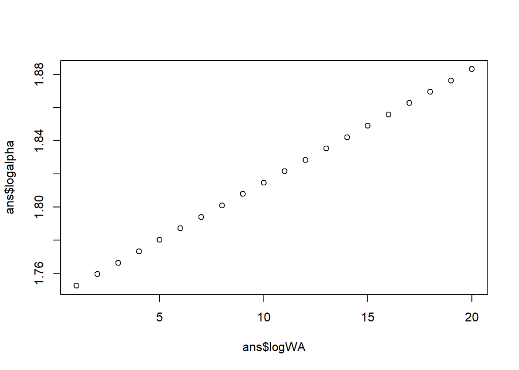

```r
  # the difference between back-simulated alpha and alpha (Ricker from SR curve)
  # functionally the same - so we can recover our estimate of alpha from the SR curve
  # and more importantly the WA regression

  # can I simulate variable alpha's?
    # how much does the difference between recoverable alpha's change depending on the prior?


predictAlpha <- function(logWA = 4:12, b0 = c(0,0), b1 = c(0,0)){
  resalpha <- resbeta <- NULL
  for( x in logWA ){
    Srep <- b0[1] + b1[1]*x
    Smsy <- b0[2] + b1[2]*x

    a <- exp(Smsy-Srep)
    logalpha.hat <- (a*(-gsl::lambert_W0(((a-1)*exp(1-1/a))/a)) + a - 1)/((a-1)*a)
    beta.hat <- logalpha.hat/Srep
    resalpha <- c(resalpha, logalpha.hat)
    resbeta <- c(resbeta, beta.hat)
  }
  data.frame(logWA = logWA, logalpha=resalpha, beta=resbeta)
}

ans <- predictAlpha(logWA = 1:20, b0 = c(4.18, 3.21), b1 = c(exp(-0.409), exp(-0.411)))
plot(ans$logWA, ans$logalpha)
```

```r
lm(ans$logalpha~ans$logWA)
```

```
##
## Call:
## lm(formula = ans$logalpha ~ ans$logWA)
##
## Coefficients:
## (Intercept)    ans$logWA
##    1.745824     0.006875
```

# 5 Comparison of Model Steps and Main Model Differences

- Identify the core differences between the two model variants
  - The parameterization of $S_{REP}$, and by that measure the exclusion of $\beta$
  - Methods of estimation: frequentist vs. bayesian (maximum likelihood vs. mcmc)
  - Propagation of error: sequential versus statistical integration approaches

The core difference between the two model types stems from the difference in the parameterization of the watershed are regression model. In the first approach applied in Parken et al. (2006), regression models are estimated for $S_{REP}$ and $S_{MSY}$, whereas the Liermann et al. (2010) only estimate a regression model for $S_{REP}$ and uses a version of the Ricker model that estimates this directly. While these model forms often given similar parameter values, Liermann et al. (2010) argues that isolating for $S_{REP}$ is simpler, more biologically interpretable, and is often required for assessment and management purposes.

# 6 Justification for continued usage of the $S_{REP}$ model

- Justify the usage of the new $S_{REP}$ model and how to choose between them:
  - The Liermann method is a direct method of estimation of $S_{REP}$
  - The Holt method is a direct estimation of $S_{MSY}$ or $S_{MAX}$
  - Model implementation in the future e.g. design matrix formatting for the inclusion of a) more model parameters, and b) varying model structures
  - What does the client want in terms of benchmarks?

# 7 Next Steps

- Next steps in model development
  - Model analysis and investigation (posterior predictive checks)
  - Consideration and discussion around $S_{REP}$ and $S_{MAX}$ as management benchmarks. This would include a potential re-parameterization of the model for $S_{MAX}$
  - Translations of both models into RTMB
  - Incorporation of a regionally hierarchical $\alpha$ parameter
  - Consider Parken’s implementation of an internal productivity covariate
  - Consider implementation of the Liermann random-walk $\alpha$
  - Development of packages/functions for ease of use by managers

# 8 Model Usage